# 2016 Presidential Campaign Contributor Data in California

Andrew Yip

11/4/2015

# The questions

This project explores the 2016 Presidential Campaign Contributor Data in California. It aims to understand the characteristics of the contributors in CA and their relationship with the candidates, their political parties, and their finances in general.

Specifically: 1. How do top-financed candidates in each party position themselves among donors? 2. How do the parties differ in the temporal and spatial dimensions of fund-raising? 3. What are the characteristics of donors in correspondance to their financial contribution to a candidate?

# Data cleaning

The data is retrieved from the [Federal Election Commission](http://fec.gov/disclosurep/PDownload.do), where the File Format is also available, describing all the fields.

First, load the libraries and read the data, and also read the candidate summary retrieved from the [FEC](http://www.fec.gov/data/CandidateSummary.do). The [metadata](http://www.fec.gov/finance/disclosure/metadata/metadataforcandidatesummary.shtml) is also available.

```r
library(dplyr)
```

```r
library(tidyr)
library(readr)
library(lubridate)
library(ggplot2)
library(rgdal)
# download.file('ftp://ftp.fec.gov/FEC/Presidential_Map/2016/P00000001/P00000001-CA.zip',
# 'data/ca.zip') unzip('data/ca.zip')

ca <- read_csv("data/P00000001-CA.csv")

# Candidate information from http://www.fec.gov/data/CandidateSummary.do
candidateSummary <- read_csv("data/CandidateSummaryAction.csv")
```

The data is then corrected for data type; mundane cloumns are removed. cmte_id, cand_id, and cand_nm are redundant, so only the cand_id is kept. We retain the correspondence of these relations in the candidateSummary DF. The date column contb_receipt_dt is converted to POSIXct class for time manipulation. receipt_desc, memo_cd, memo_text, form_tp, tran_id, and election_tp are redacted as they only contain mundane information, the omission of which would not affect the analysis. contbr_st is “CA” for all observations so can also be eliminated. The 18 columns reduce to 9.

```r
ca$contb_receipt_dt <- dmy(ca$contb_receipt_dt)
ca <- ca %>% select(cand_id, contbr_nm:contbr_city, contbr_zip:contb_receipt_dt,
    file_num) %>% data.frame
```

# First look at the candidates

First, note that there are 21 candidates with contributions from CA, let’s look at the candidates’ key financial summaries, with fractions of individual contributions in total contribtution. It is arranged by descending total contribution. Note that we are exploring the general financial characteristics of the candidates on contributions from all states.

```r
dsConvert <- function(x) gsub("[$,]", "", x) %>% as.numeric()

cand <- candidateSummary %>% filter(can_id %in% unique(ca$cand_id)) %>% select(can_id,
    can_nam, can_par_aff, can_cit, can_sta, can_zip:ind_uni_con, par_com_con:tot_con)
lapply(7:12, function(x) cand[[x]] <<- cand[[x]] %>% dsConvert())
```

[output not shown]

```r
cand %>% mutate(ind_ite_fra = signif(ind_ite_con/tot_con, 3), ind_uni_fra = signif(ind_uni_con/tot_con,
    3)) %>% select(can_nam, can_par_aff, ind_ite_fra, ind_uni_fra, tot_con) %>%
    arrange(tot_con %>% desc) %>% head
```

```
## Source: local data frame [6 x 5]
##
##                     can_nam can_par_aff ind_ite_fra ind_uni_fra  tot_con
##                       (chr)       (chr)       (dbl)       (dbl)    (dbl)
## 1   CLINTON, HILLARY RODHAM         DEM       0.815      0.1730 76995137
## 2          SANDERS, BERNARD         DEM       0.233      0.7670 39953744
## 3  CARSON, BENJAMIN S SR MD         REP       0.373      0.6270 31336023
## 4 CRUZ, RAFAEL EDWARD (TED)         REP       0.577      0.4210 26316661
## 5                 BUSH, JEB         REP       0.929      0.0502 24779030
## 6              RUBIO, MARCO         REP       0.764      0.2190 14842196
```

# Fund-raising timing and spatial patterns

We now explore the CA contributor data in both time and space.

# Temporal distribution

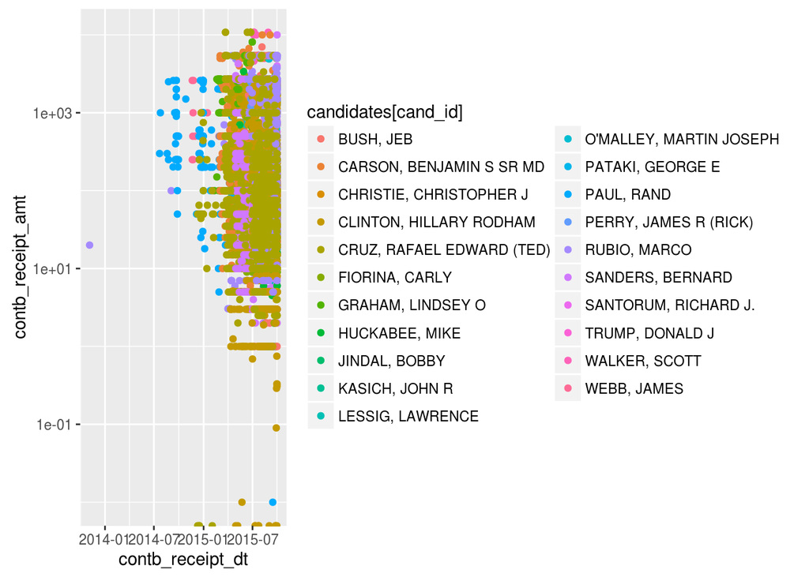

```r
candidates <- candidateSummary$can_nam
names(candidates) <- candidateSummary$can_id
ca %>% ggplot(aes(x = contb_receipt_dt, y = contb_receipt_amt, color = candidates[cand_id])) +
    geom_point() + scale_y_log10()
```

The raw time-series in fund-raising for each candidate is messy. Let’s explore party-wide fund-raising by day.

```r
parties <- candidateSummary$can_par_aff
names(parties) <- candidateSummary$can_id
par_receipt <- ca %>% mutate(par_aff = parties[cand_id]) %>% group_by(par_aff,
    contb_receipt_dt) %>% summarize(party_receipt_amt = sum(contb_receipt_amt))
par_receipt %>% group_by(par_aff) %>% summarize(min = min(party_receipt_amt),
    median = median(party_receipt_amt), mean = mean(party_receipt_amt), max = max(party_receipt_amt),
    count = n())
```

```
## Source: local data frame [3 x 6]
##
##   par_aff       min   median      mean      max count
##     (chr)     (dbl)    (dbl)     (dbl)    (dbl) (int)
## 1     DEM      6.00 68940.35 91886.399 430395.0   173
## 2     REP -35620.68 13008.75 40700.293 987489.1   269
## 3     UNK     25.00   500.00  1144.469   6000.0    60
```

The summary shows a performance of the parties in time (day). We notice negative contributions in a large amount with the Republican party. Let’s explore the specific entries.

```r
par_receipt %>% filter(party_receipt_amt < 0)
```

```
## Source: local data frame [5 x 3]
## Groups: par_aff [1]
##
##   par_aff contb_receipt_dt party_receipt_amt
##     (chr)           (time)             (dbl)
## 1     REP       2014-09-03           -160.00
## 2     REP       2014-09-30          -1950.00
## 3     REP       2015-04-06          -1292.00
## 4     REP       2015-05-09           -220.00
## 5     REP       2015-06-12         -35620.68
```

```r
# ca %>% filter(contb_receipt_amt < 0, contb_receipt_dt == ymd('2015-06-12')
# )
```

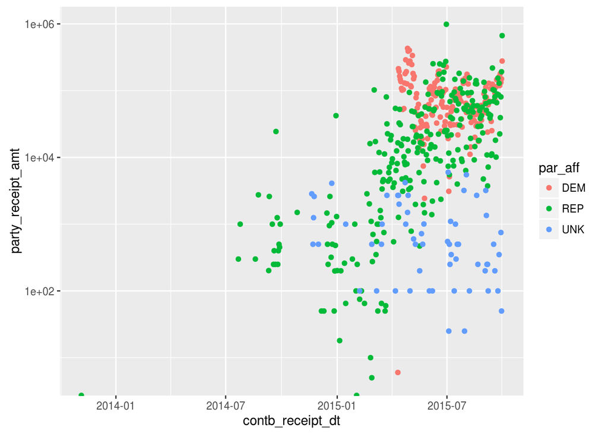

```r
par_receipt %>% ggplot(aes(x = contb_receipt_dt, y = party_receipt_amt, color = par_aff)) +
    geom_point() + scale_y_log10()
```

Demoncrats’ contributions concentrate in late spring early summer in 2015, while Republicans’ contributions are spread out more evenly through the year. There’s also a contribution at a more concentrated order of magnitude among Demoncrats, while Republican contributions span several orders of magnitude.

# Spatial distribution

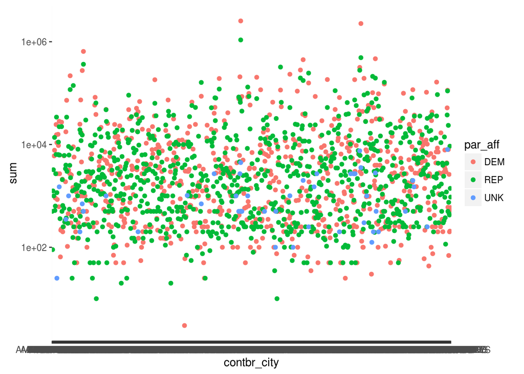

```r
ca %>% mutate(par_aff = parties[cand_id]) %>% group_by(par_aff, contbr_city) %>%
    summarize(sum = sum(contb_receipt_amt)) %>% ggplot(aes(x = contbr_city,
    y = sum, color = par_aff)) + geom_point() + scale_y_log10()
```

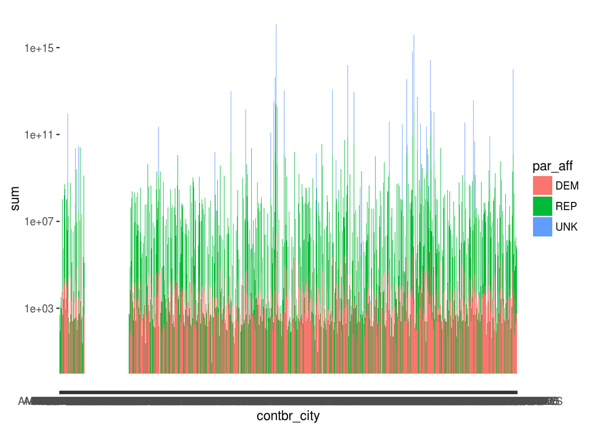

```r
ca %>% mutate(par_aff = parties[cand_id]) %>% group_by(par_aff, contbr_city) %>%
    summarize(sum = sum(contb_receipt_amt)) %>% ggplot(aes(x = contbr_city,
    y = sum, fill = par_aff)) + geom_bar(stat = "identity") + scale_y_log10()
```

Again, there are a lot of cities and the plot gets messy. To lower the dimension, we perform the analysis via summing the contributions by zip-code, and spatially illustrate the results by political parties.

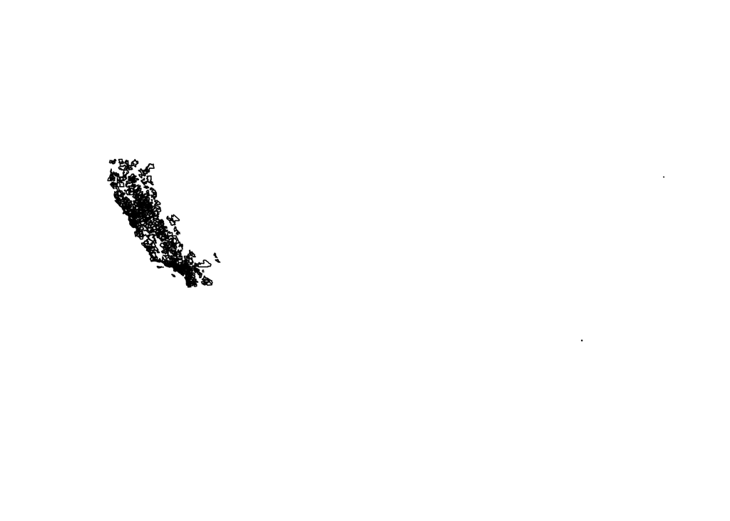

```r
# download country/zipcode shapefiles
# download.file('http://www2.census.gov/geo/tiger/GENZ2014/shp/cb_2014_us_zcta510_500k.zip',
# 'data/zipcode.zip',quiet = T) unzip('data/zipcode.zip', exdir = 'data/')
# zipcode <- readOGR('data/', 'cb_2014_us_zcta510_500k', stringsAsFactors =
# F) # substringing the first 5 characters ca_zipcode <- ca$contbr_zip %>%
# substr(., 1, 5) %>% unique zipcode <- zipcode[zipcode$ZCTA5CE10 %in%
# ca_zipcode, ] save(zipcode, file = 'data/zipcode.RData')
load("data/zipcode.RData")
# NOTE: the above code operates on a file larger than github allows. a
# subsetted version is saved after processing for preliminary visualization
# below

plot(zipcode["ZCTA5CE10"])
```

A quick look of the spatial plot of the zipcode shows us something strange about the data, namely, some remote areas not in CA are plotted. It is relvealed that zipcode of 11205 and 32804 are included in the data. In addition, zipcodes are really too fine a spatial scale for visualization (at 1348 polygons).

# Financing characteristics

First, we need to clean the data for duplicate categories such as “SELF-EMPLOYED”, “SELF EMPLOYED”, “SELF”, “NONE”, “NOT EMPLOYED”, etc in the employer column. For this study, we will group them using the occupation column under “NOT EMPLOYED” and “SELF EMPLOYED”. Before doing so, let’s side-track and investigate whether there’s a self-perceived difference within the “NOT EMPLOYED” and “SELF EMPLOYED” groups in reported employer and their compaign contribution amount.

```r
ca %>% filter(contbr_occupation == "NOT EMPLOYED") %>% group_by(contbr_employer) %>%
    summarize(n = n(), mean = mean(contb_receipt_amt)) %>% arrange(n %>% desc)
```

```
## Source: local data frame [9 x 3]
##
##        contbr_employer     n       mean
##                  (chr) (int)      (dbl)
## 1         NOT EMPLOYED  4350  138.73866
## 2                  N/A   247  725.49866
## 3                 NONE   103   44.27796
## 4                LADWP     6   44.33333
## 5             NONENONE     3  283.33333
## 6           CROSSROADS     1   50.00000
## 7 LYNCEAN TECHNOLOGIES     1  100.00000
## 8                   NA     1 2700.00000
## 9        SELF-EMPLOYED     1  500.00000
```

```r
ca %>% filter(contbr_occupation == "SELF EMPLOYED") %>% group_by(contbr_employer) %>%
    summarize(n = n(), mean = mean(contb_receipt_amt)) %>% arrange(n %>% desc)
```

```
## Source: local data frame [36 x 3]
##
##                  contbr_employer     n      mean
##                            (chr) (int)     (dbl)
## 1                  SELF EMPLOYED   100 169.67690
## 2                           SELF    22 306.62727
## 3                ULTIMATE SOURCE    13  43.84615
## 4                   NOT EMPLOYED    11  79.23182
## 5           INSYNC LEARNING, LLC     8  18.75000
## 6                  SELF-EMPLOYED     6 371.66667
## 7          INFORMATION SCIENTIST     4  62.50000
## 8  COMMERCIAL TRANSPORT CONCEPTS     3 133.33333
## 9                          L & J     3  31.66667
## 10                  RMN SERVICES     3  74.00000
## ..                           ...   ...       ...
```

```r
ca$contbr_employer[ca$contbr_occupation == "NOT EMPLOYED"] <- "NOT EMPLOYED"
ca$contbr_employer[ca$contbr_occupation == "SELF EMPLOYED"] <- "SELF EMPLOYED"
```

We now examine the top occupation and companies by head count and look at their average contribution per head.

```r
ca %>% mutate(par_aff = parties[cand_id]) %>% group_by(par_aff, contbr_occupation) %>%
    summarize(n = n(), mean = mean(contb_receipt_amt)) %>% arrange(n %>% desc) %>%
    slice(1:5)
```

```
## Source: local data frame [15 x 4]
## Groups: par_aff [3]
##
##    par_aff                      contbr_occupation     n     mean
##      (chr)                                  (chr) (int)    (dbl)
## 1      DEM                           NOT EMPLOYED  4698 167.4632
## 2      DEM                                RETIRED  2948 397.5749
## 3      DEM                               ATTORNEY  1494 910.0510
## 4      DEM                  INFORMATION REQUESTED   966 386.8384
## 5      DEM                              PHYSICIAN   565 476.0615
## 6      REP                                RETIRED  9098 227.0447
## 7      REP INFORMATION REQUESTED PER BEST EFFORTS  1184 430.3169
## 8      REP                              HOMEMAKER   974 885.6492
## 9      REP                               ATTORNEY   445 881.5379
## 10     REP                               ENGINEER   358 218.9918
## 11     UNK                                RETIRED    13 286.1662
## 12     UNK                               ATTORNEY     8 784.3750
## 13     UNK               DEPUTY DISTRICT ATTORNEY     7 100.0000
## 14     UNK                           NOT EMPLOYED     5 880.0000
## 15     UNK                  REINSURANCE EXECUTIVE     4 100.0000
```

Democrats top supporters are the not employed, retired, and attorney. In contrast, Republicans see retirees the top contributors, following with the homemaker and attorney. Democrats average contributions on the attorneys and retired crowds are both higher than those of Republicans. Homemaker makes a personal surprise in both numbers and the average amount of contribution. In the following we compile the top occupations for both parties ranked by accumulated head counts and examine their respective average contributions.

```r
occupation <- left_join(ca %>% mutate(par_aff = parties[cand_id]) %>% group_by(par_aff,
    contbr_occupation) %>% summarize(n = n(), mean = mean(contb_receipt_amt)) %>%
    select(par_aff, contbr_occupation, n) %>% spread(par_aff, n) %>% select(-UNK) %>%
    filter(complete.cases(.)) %>% mutate(total = DEM + REP) %>% arrange(total %>%
    desc), ca %>% mutate(par_aff = parties[cand_id]) %>% group_by(par_aff, contbr_occupation) %>%
    summarize(n = n(), mean = mean(contb_receipt_amt)) %>% select(par_aff, contbr_occupation,
    mean) %>% spread(par_aff, mean) %>% select(-UNK) %>% filter(complete.cases(.)),
    by = "contbr_occupation") %>% rename(DEM.n = DEM.x, REP.n = REP.x, DEM.mean = DEM.y,
    REP.mean = REP.y) %>% mutate(gap = DEM.mean - REP.mean)

occupation %>% slice(1:15)
```

```
## Source: local data frame [15 x 7]
##
##        contbr_occupation DEM.n REP.n total  DEM.mean  REP.mean        gap
##                    (chr) (int) (int) (int)     (dbl)     (dbl)      (dbl)
## 1                RETIRED  2948  9098 12046  397.5749  227.0447  170.53017
## 2           NOT EMPLOYED  4698    10  4708  167.4632   59.5660  107.89724
## 3               ATTORNEY  1494   445  1939  910.0510  881.5379   28.51302
## 4              HOMEMAKER   462   974  1436 1279.5036  885.6492  393.85439
## 5  INFORMATION REQUESTED   966   251  1217  386.8384  663.2074 -276.36905
## 6              PHYSICIAN   565   306   871  476.0615  381.5837   94.47788
## 7                    CEO   438   284   722 1449.5383 1124.2706  325.26777
## 8                TEACHER   541   178   719  208.3525  146.9440   61.40849
## 9               ENGINEER   346   358   704  370.0881  218.9918  151.09628
## 10            CONSULTANT   485   164   649  711.0532  555.1738  155.87935
## 11             PRESIDENT   253   338   591 1396.3033 1126.4857  269.81764
## 12     SOFTWARE ENGINEER   478    32   510  226.5814  452.6000 -226.01864
## 13               MANAGER   263   173   436  594.5601  484.7216  109.83855
## 14                LAWYER   266   151   417 1103.5150  615.1290  488.38599
## 15                 OWNER   184   231   415 1034.5903  845.5418  189.04850
```

Next we look at top employers.

```r
employer <- left_join(ca %>% mutate(par_aff = parties[cand_id]) %>% group_by(par_aff,
    contbr_employer) %>% summarize(n = n(), mean = mean(contb_receipt_amt)) %>%
    select(par_aff, contbr_employer, n) %>% spread(par_aff, n) %>% select(-UNK) %>%
    filter(complete.cases(.)) %>% mutate(total = DEM + REP) %>% arrange(total %>%
    desc), ca %>% mutate(par_aff = parties[cand_id]) %>% group_by(par_aff, contbr_employer) %>%
    summarize(n = n(), mean = mean(contb_receipt_amt)) %>% select(par_aff, contbr_employer,
    mean) %>% spread(par_aff, mean) %>% select(-UNK) %>% filter(complete.cases(.)),
    by = "contbr_employer") %>% rename(DEM.n = DEM.x, REP.n = REP.x, DEM.mean = DEM.y,
    REP.mean = REP.y) %>% mutate(gap = DEM.mean - REP.mean)

employer %>% slice(1:20)
```

```
## Source: local data frame [20 x 7]
##
##          contbr_employer DEM.n REP.n total   DEM.mean    REP.mean
##                    (chr) (int) (int) (int)      (dbl)       (dbl)
## 1                RETIRED  1092  8926 10018  384.12781   227.74664
## 2           NOT EMPLOYED  5802    18  5820  185.61111    53.92556
## 3          SELF-EMPLOYED  3191  1586  4777  834.18986   631.55736
## 4                    N/A  2520   265  2785  714.73518   286.78460
## 5          SELF EMPLOYED  1298   941  2239  149.19163   294.09236
## 6                   SELF   395   938  1333  152.09699   259.55471
## 7  INFORMATION REQUESTED   929   235  1164  375.68607   694.94634
## 8                   NONE   201   616   817   53.02358   184.81670
## 9              HOMEMAKER     1   790   791 2700.00000  1018.37766
## 10                         277   106   383 -712.53617 -1256.37858
## 11   STATE OF CALIFORNIA   137    49   186  300.30693   262.00000
## 12                GOOGLE   165     3   168  621.32364   583.33333
## 13     KAISER PERMANENTE    85    44   129  428.66424   248.34091
## 14   STANFORD UNIVERSITY   112    15   127  621.71714   715.66667
## 15                  UCLA    86    11    97  342.21140   243.18182
## 16                    NA    17    64    81  246.80588   119.48375
## 17            APPLE INC.    70     7    77  176.53157   625.22857
## 18            UNEMPLOYED     1    76    77   91.00000   118.01526
## 19    LOS ANGELES COUNTY    67     8    75  265.81940   152.50000
## 20           WELLS FARGO    48    18    66  653.10250   112.05556
## Variables not shown: gap (dbl)
```

A quick inspection of the list shows that the universities and tech companies are democrat heavy, as well as the government employee of the California State and the LA County.

# Final Plots and Summary

## Plot 1: Candidate Positioning in Fund-raising

In relation to the first question, let’s look at the relations of the size of total contribution, the weight of unitemized contributions (under $200), and the party affiliation.

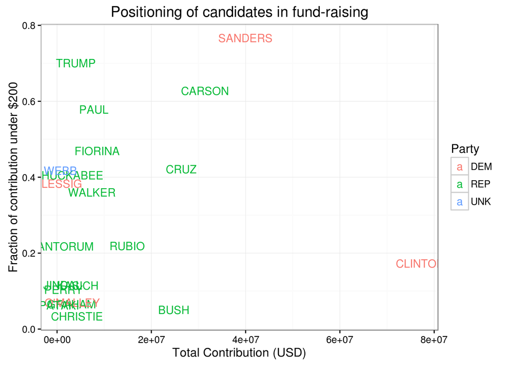

```r
cand %>% mutate(ind_ite_fra = signif(ind_ite_con/tot_con, 3), ind_uni_fra = signif(ind_uni_con/tot_con,
    3)) %>% select(can_nam, can_par_aff, ind_ite_fra, ind_uni_fra, tot_con) %>%
    ggplot(aes(x = tot_con, y = ind_uni_fra, color = can_par_aff, label = sapply(strsplit(can_nam,
        split = ",", fixed = T), function(x) x[1]))) + geom_text() + theme_bw() +
    labs(x = "Total Contribution (USD)", y = "Fraction of contribution under $200",
        color = "Party", title = "Positioning of candidates in fund-raising")
```

Out of the four democratic candidates who received contributions from CA, Clinton and Sanders lead in total contributions, with very different constituents of the funding source. 80% of Sanders’ individual contributions are small contributions under $200 each, where Clinton stands at 20%. Also note that Clinton receives double the amount of contributions to that of Sanders. Among Republican candidates, Carson receives most contribution in aggregate, while the top three Republican candidates in terms of total contributions do not see such a big variance as among the Democrats. It is also interesting to note that the top three Republican candidates span the space among the different proportions of small contributions, with Carson catering to the small donars, and Bush to the large, and Cruz holding a middle position. Personally, it is surprising to see Trump has a rather low percentage in contributions greater than $200, while his total contribution is not as high, contrary to his media image. It also seems that the [Hotelling’s law](https://en.wikipedia.org/wiki/Hotelling%27s_law) does not hold in terms of political positioning on total contributions within one’s political party, where differentiation in the size of individual contributions pays off.

## Plot 2: Temporal aggregation in contribution

In relation to the second question we explore the temporal behavior in campaign contribution for the 9 largest occupations for each party respectively from May 2015.

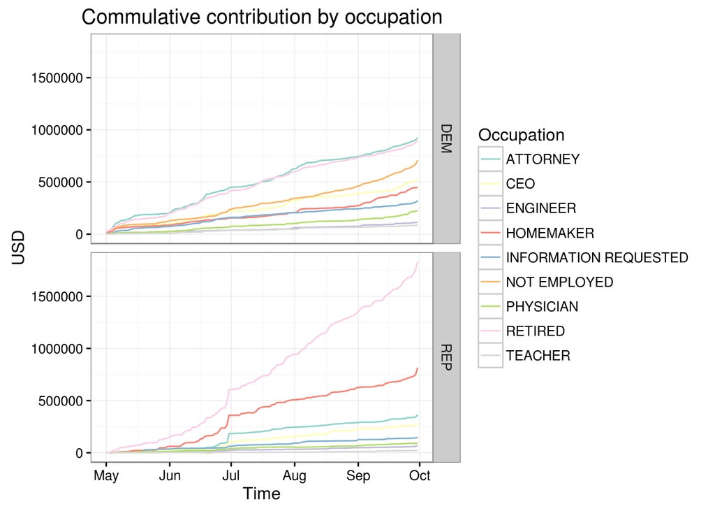

```r
ca %>% mutate(t = ymd(contb_receipt_dt), party = parties[cand_id]) %>% filter(contbr_occupation %in%
    occupation$contbr_occupation[1:9], party %in% c("DEM", "REP"), t > "2015-05-01") %>%
    group_by(party, contbr_occupation, t) %>% summarize(sum = sum(contb_receipt_amt)) %>%
    mutate(cumsum = with_order(t, cumsum, sum)) %>% ggplot(aes(x = t, y = cumsum,
    color = contbr_occupation)) + geom_line() + facet_grid(party ~ .) + scale_color_brewer(palette = "Set3") +
    theme_bw() + labs(x = "Time", y = "USD", color = "Occupation", title = "Commulative contribution by occupation")
```

Here we observe an obvious kink in the republican total contribution at the end of June, and a steady increase in total contribution from the two most important sectors, retired and homemakers. On the contrast, demoncratic total contribution sees a more linear trend from the top performing sectors, the attorneys and the retired. The not employed is a particular strong hold with the Democrats, with an increasing trend over time.

## Plot 3: A simple model on party affiliation and contribution amount

To investigate the third question of how the characteristics of the donor relate to their support of a particular party. We opt to build a linear model to predict party affiliation based on the donor’s contribution amount and other traits. Since the dimensions of the factor variables are large, we opt to only take the top 15 occupations combined across parties as a predictor.

```r
partyint <- c(0, 1)
names(partyint) <- c("DEM", "REP")
modeldata <- ca %>% mutate(par_aff = partyint[parties[cand_id]]) %>% filter(par_aff %in%
    c(0, 1), contbr_occupation %in% occupation$contbr_occupation[1:15]) %>%
    select(contb_receipt_amt, par_aff, contbr_occupation)
model <- lm(par_aff ~ contb_receipt_amt + contbr_occupation, modeldata)

model
```

```
##
## Call:
## lm(formula = par_aff ~ contb_receipt_amt + contbr_occupation,
##     data = modeldata)
##
## Coefficients:
##                            (Intercept)
##                              2.625e-01
##                      contb_receipt_amt
##                             -3.652e-05
##                   contbr_occupationCEO
##                              1.791e-01
##            contbr_occupationCONSULTANT
##                              1.473e-02
##              contbr_occupationENGINEER
##                              2.567e-01
##             contbr_occupationHOMEMAKER
##                              4.527e-01
## contbr_occupationINFORMATION REQUESTED
##                             -4.004e-02
##                contbr_occupationLAWYER
##                              1.335e-01
##               contbr_occupationMANAGER
##                              1.544e-01
##          contbr_occupationNOT EMPLOYED
##                             -2.543e-01
##                 contbr_occupationOWNER
##                              3.281e-01
##             contbr_occupationPHYSICIAN
##                              1.050e-01
##             contbr_occupationPRESIDENT
##                              3.548e-01
##               contbr_occupationRETIRED
##                              5.026e-01
##     contbr_occupationSOFTWARE ENGINEER
##                             -1.910e-01
##               contbr_occupationTEACHER
##                             -7.874e-03
```

```r
anova(model)
```

```
## Analysis of Variance Table
##
## Response: par_aff
##                      Df Sum Sq Mean Sq F value    Pr(>F)
## contb_receipt_amt     1   22.0  21.976  138.32 < 2.2e-16 ***
## contbr_occupation    14 2457.8 175.555 1104.97 < 2.2e-16 ***
## Residuals         27364 4347.5   0.159
## ---
## Signif. codes:  0 '***' 0.001 '**' 0.01 '*' 0.05 '.' 0.1 ' ' 1
```

The model illustrates significance in predicting party support based on donor’s occupation and contribution, where the occupations have most weight in terms of predicting one’s affiliation. The signs of effect of the professions agree with the prior explorations.

# Reflection

The categorical columns have been messy and difficult to clean due to the inherent duplicative nature of self-reported fields. In particular, the self-employed and not-employed categories overlap without clear delineation. The lack of finer spatial grouping of the donors other than zipcode has made a spatial investigation of the data difficult. This data-analysis exerperience has been both challenging and rewarding. I look forward to more predictive analyses on election data with more scalar variables, which could include household income, family size, home size, etc, for a better characterization of the donors behavior with their traits.